# Lab 6

Author

Melissa LaMette

# Packages

```python
import pandas as pd
import numpy as np
from sklearn.pipeline import Pipeline
from sklearn.compose import make_column_selector, ColumnTransformer
from sklearn.preprocessing import StandardScaler, OneHotEncoder, PolynomialFeatures
from sklearn.linear_model import LinearRegression, Ridge, Lasso, ElasticNet
from sklearn.model_selection import train_test_split, cross_val_score
from sklearn.metrics import r2_score, mean_squared_error
from plotnine import *
from sklearn.model_selection import GridSearchCV
```

# Data, Data Cleaning

```python
# Read the data
hitters = pd.read_csv("Hitters.csv")
hitters

# Drop other NAs
hitters = hitters.dropna()

hitters
```

|  | AtBat | Hits | HmRun | Runs | RBI | Walks | Years | CAtBat | CHits | CHmRun | CRuns | CRBI | CWalks | League | Division | PutOuts | Assists | Errors | Salary | NewLeague |
| --- | --- | --- | --- | --- | --- | --- | --- | --- | --- | --- | --- | --- | --- | --- | --- | --- | --- | --- | --- | --- |
| 1 | 315 | 81 | 7 | 24 | 38 | 39 | 14 | 3449 | 835 | 69 | 321 | 414 | 375 | N | W | 632 | 43 | 10 | 475.0 | N |
| 2 | 479 | 130 | 18 | 66 | 72 | 76 | 3 | 1624 | 457 | 63 | 224 | 266 | 263 | A | W | 880 | 82 | 14 | 480.0 | A |
| 3 | 496 | 141 | 20 | 65 | 78 | 37 | 11 | 5628 | 1575 | 225 | 828 | 838 | 354 | N | E | 200 | 11 | 3 | 500.0 | N |
| 4 | 321 | 87 | 10 | 39 | 42 | 30 | 2 | 396 | 101 | 12 | 48 | 46 | 33 | N | E | 805 | 40 | 4 | 91.5 | N |
| 5 | 594 | 169 | 4 | 74 | 51 | 35 | 11 | 4408 | 1133 | 19 | 501 | 336 | 194 | A | W | 282 | 421 | 25 | 750.0 | A |
| ... | ... | ... | ... | ... | ... | ... | ... | ... | ... | ... | ... | ... | ... | ... | ... | ... | ... | ... | ... | ... |
| 317 | 497 | 127 | 7 | 65 | 48 | 37 | 5 | 2703 | 806 | 32 | 379 | 311 | 138 | N | E | 325 | 9 | 3 | 700.0 | N |
| 318 | 492 | 136 | 5 | 76 | 50 | 94 | 12 | 5511 | 1511 | 39 | 897 | 451 | 875 | A | E | 313 | 381 | 20 | 875.0 | A |
| 319 | 475 | 126 | 3 | 61 | 43 | 52 | 6 | 1700 | 433 | 7 | 217 | 93 | 146 | A | W | 37 | 113 | 7 | 385.0 | A |
| 320 | 573 | 144 | 9 | 85 | 60 | 78 | 8 | 3198 | 857 | 97 | 470 | 420 | 332 | A | E | 1314 | 131 | 12 | 960.0 | A |
| 321 | 631 | 170 | 9 | 77 | 44 | 31 | 11 | 4908 | 1457 | 30 | 775 | 357 | 249 | A | W | 408 | 4 | 3 | 1000.0 | A |

263 rows × 20 columns

# Part 1: Different Model Specs

## Regression without regularization

```python
# Pipeline - Ordinary Linear Regression

X = hitters.drop("Salary", axis = 1) # we drop Salary we want all columns as predictors
y = hitters["Salary"]


ct = ColumnTransformer(
  [("dummify",
    OneHotEncoder(sparse_output = False,handle_unknown='ignore'), # take it out and run it to see error
    make_column_selector(dtype_include=object)),
      ("standardize",
    StandardScaler(),
    make_column_selector(dtype_include=np.number))],
  remainder = "passthrough")


lr_pipeline_1 = Pipeline(
  [("preprocessing", ct),
  ("linear_regression", LinearRegression())]
).set_output(transform="pandas")
```

```python
# look at columns
dummy = ct.fit_transform(X)
dummy

# get columns and check length
col = list(dummy.columns)
len(col)
```

```
22
```

```python
# Fit
lr_fitted_1 = lr_pipeline_1.fit(X, y)
lr_fitted_1 # diagram

# Coefficients
coef_1 = lr_fitted_1.named_steps['linear_regression'].coef_

linear_coefficients = pd.DataFrame({'dependent_variable': col,'coefficients': coef_1})
linear_coefficients
```

|  | dependent_variable | coefficients |
| --- | --- | --- |
| 0 | dummify__League_A | -31.2997115176 |
| 1 | dummify__League_N | 31.2997115176 |
| 2 | dummify__Division_E | 58.4246228184 |
| 3 | dummify__Division_W | -58.4246228184 |
| 4 | dummify__NewLeague_A | 12.3811625542 |
| 5 | dummify__NewLeague_N | -12.3811625542 |
| 6 | standardize__AtBat | -291.0945556972 |
| 7 | standardize__Hits | 337.8304794815 |
| 8 | standardize__HmRun | 37.8538367643 |
| 9 | standardize__Runs | -60.5724786055 |
| 10 | standardize__RBI | -26.9949837899 |
| 11 | standardize__Walks | 135.0738969513 |
| 12 | standardize__Years | -16.6933588751 |
| 13 | standardize__CAtBat | -391.0386546635 |
| 14 | standardize__CHits | 86.6876166377 |
| 15 | standardize__CHmRun | -14.1817233230 |
| 16 | standardize__CRuns | 480.7471347708 |
| 17 | standardize__CRBI | 260.6898858052 |
| 18 | standardize__CWalks | -213.8922586429 |
| 19 | standardize__PutOuts | 78.7612963949 |
| 20 | standardize__Assists | 53.7324897347 |
| 21 | standardize__Errors | -22.1608621742 |

```python
# Cross val - the more negative the higher the error
scores = cross_val_score(lr_pipeline_1, X, y, cv = 5, scoring = 'neg_mean_squared_error')
-scores.mean()
```

```
121136.31031816891
```

### Mean Squared Error:

121136.31031816891

```python
# Pipeline 2 - Ridge Regression


ct2 = ColumnTransformer(
  [("dummify",
    OneHotEncoder(sparse_output = False,handle_unknown='ignore'), # take it out and run it to see error
    make_column_selector(dtype_include=object)),
    ("standardize",
    StandardScaler(),
    make_column_selector(dtype_include=np.number))
  ],
  remainder = "passthrough")


lr_pipeline_2 = Pipeline(
  [("preprocessing", ct2),
  ("ridge_regression", Ridge(alpha = 1))]
).set_output(transform="pandas")
```

```python
# look at columns
dummy2 = ct2.fit_transform(X)
dummy2

# get columns and check length
col2 = list(dummy2.columns)
len(col2)
```

```
22
```

```python
# Fit
lr_fitted_2 = lr_pipeline_2.fit(X, y)
lr_fitted_2 # diagram

# Coefficients
coef_2 = lr_fitted_2.named_steps['ridge_regression'].coef_

ridge_coefficients = pd.DataFrame({'dependent_variable': col2,'coefficients': coef_2})
ridge_coefficients
```

[output not shown]

League is no longer a negative coefficient

```python
# Tuning lambda aka alpha

# Your existing list of numbers
alphas = [0.001, 0.01, 0.1, 1, 10]


alpha_tune = {'ridge_regression__alpha': alphas} # need two underscores to separate name of step

gscv = GridSearchCV(lr_pipeline_2, alpha_tune, cv = 5, scoring='neg_mean_squared_error')

gscv_fitted = gscv.fit(X, y)

results = pd.DataFrame(gscv_fitted.cv_results_)
results

pd.DataFrame(data = {"alpha": results['param_ridge_regression__alpha'], "scores": -results['mean_test_score']})
```

|  | alpha | scores |
| --- | --- | --- |
| 0 | 0.001 | 121124.458592 |
| 1 | 0.01 | 121022.903286 |
| 2 | 0.1 | 120343.621067 |
| 3 | 1 | 119144.432677 |
| 4 | 10 | 119348.984776 |

The best MSE was for model with alpha is 1.

## Lasso Regression

```python
# Pipeline3 - Lasso
ct3 = ColumnTransformer(
  [
    ("dummify",
    OneHotEncoder(sparse_output = False, handle_unknown='ignore'), # take it out and run it to see error
    make_column_selector(dtype_include=object)),
    ("standardize",
    StandardScaler(),
    make_column_selector(dtype_include=np.number))
  ],
  remainder = "passthrough"
)

lr_pipeline_3 = Pipeline(
  [("preprocessing", ct3),
  ("lasso", Lasso(alpha = 1))]
).set_output(transform="pandas")
```

```python
# look at columns
dummy3 = ct3.fit_transform(X)
dummy3

# get columns and check length
col3 = list(dummy3.columns)
len(col3)
# Fit on entire dataset
lr_fitted3 = lr_pipeline_3.fit(X, y)

# Estimating Betas for all variables - fit named steps
coef_3 = lr_fitted3.named_steps['lasso'].coef_

# Coefficients
pd.options.display.float_format = '{:.10f}'.format # removes scientific notation
lasso_coefficients = pd.DataFrame({'dependent_variable': col3,'coefficients': coef_3})
lasso_coefficients
```

|  | dependent_variable | coefficients |
| --- | --- | --- |
| 0 | dummify__League_A | -35.8260721116 |
| 1 | dummify__League_N | 0.0000000000 |
| 2 | dummify__Division_E | 114.4129511339 |
| 3 | dummify__Division_W | -0.0000000000 |
| 4 | dummify__NewLeague_A | 0.0000000000 |
| 5 | dummify__NewLeague_N | -0.0000000000 |
| 6 | standardize__AtBat | -282.3709571733 |
| 7 | standardize__Hits | 304.3595085842 |
| 8 | standardize__HmRun | 11.1270220294 |
| 9 | standardize__Runs | -24.9665071114 |
| 10 | standardize__RBI | -0.0000000000 |
| 11 | standardize__Walks | 120.6952750217 |
| 12 | standardize__Years | -34.9481480726 |
| 13 | standardize__CAtBat | -162.6397937686 |
| 14 | standardize__CHits | 0.0000000000 |
| 15 | standardize__CHmRun | 14.2259931570 |
| 16 | standardize__CRuns | 375.5655192080 |
| 17 | standardize__CRBI | 192.6108916693 |
| 18 | standardize__CWalks | -189.6446419429 |
| 19 | standardize__PutOuts | 78.7603657546 |
| 20 | standardize__Assists | 41.9966795040 |
| 21 | standardize__Errors | -18.4793783967 |

```python
# Your existing list of numbers
alphas2 = [0.001, 0.01, 0.1, 1, 10]


alpha_tune2 = {'lasso__alpha': alphas} # need two underscores to separate name of step

gscv2 = GridSearchCV(lr_pipeline_3, alpha_tune2, cv = 5, scoring='neg_mean_squared_error')

gscv_fitted2 = gscv2.fit(X, y)

results2 = pd.DataFrame(gscv_fitted2.cv_results_)
results2

lasso1 = pd.DataFrame(data = {"alpha": results2['param_lasso__alpha'], "scores": -results2['mean_test_score']})
lasso1.sort_values(by = 'scores')
```

|  | alpha | scores |
| --- | --- | --- |
| 3 | 1 | 119761.5874074131 |
| 2 | 0.1000000000 | 120682.2526374537 |
| 1 | 0.0100000000 | 120964.7646861800 |
| 0 | 0.0010000000 | 120994.1798148055 |
| 4 | 10 | 121828.1413333863 |

the alpha with the best MSE is alpha is 1

## Elastic Net

```python
# Pipeline 4 - Elastic Net

ct4 = ColumnTransformer(
  [
    ("dummify",
    OneHotEncoder(sparse_output = False, handle_unknown='ignore'), # take it out and run it to see error
    make_column_selector(dtype_include=object)),
    ("standardize",
    StandardScaler(),
    make_column_selector(dtype_include=np.number))
  ],
  remainder = "passthrough"
)

lr_pipeline_4 = Pipeline(
  [("preprocessing", ct4),
  ("elastic", ElasticNet(alpha = 0.1, l1_ratio = 0.8))]
).set_output(transform="pandas")
```

```python
# look at columns
dummy4 = ct4.fit_transform(X)
dummy4

# get columns and check length
col4 = list(dummy4.columns)
len(col4)

# Fit on entire dataset
lr_fitted4 = lr_pipeline_4.fit(X, y)

# Estimating Betas for all variables - fit named steps
coef_4 = lr_fitted4.named_steps['elastic'].coef_


# Coefficients
pd.options.display.float_format = '{:.10f}'.format # removes scientific notation
elastic_coefficients = pd.DataFrame({'dependent_variable': col4,'coefficients': coef_4})
elastic_coefficients
```

|  | dependent_variable | coefficients |
| --- | --- | --- |
| 0 | dummify__League_A | -26.2373908574 |
| 1 | dummify__League_N | 26.2380806552 |
| 2 | dummify__Division_E | 60.7491423159 |
| 3 | dummify__Division_W | -60.7501381719 |
| 4 | dummify__NewLeague_A | 9.6789802517 |
| 5 | dummify__NewLeague_N | -9.6811304094 |
| 6 | standardize__AtBat | -184.9956556592 |
| 7 | standardize__Hits | 200.5499572042 |
| 8 | standardize__HmRun | -3.2770799743 |
| 9 | standardize__Runs | 9.3585423899 |
| 10 | standardize__RBI | 9.3793983339 |
| 11 | standardize__Walks | 97.5555230618 |
| 12 | standardize__Years | -52.1810198046 |
| 13 | standardize__CAtBat | -56.8535181928 |
| 14 | standardize__CHits | 110.7593239587 |
| 15 | standardize__CHmRun | 59.2610886409 |
| 16 | standardize__CRuns | 163.2161702176 |
| 17 | standardize__CRBI | 104.7648158435 |
| 18 | standardize__CWalks | -125.7537732307 |
| 19 | standardize__PutOuts | 76.8131912524 |
| 20 | standardize__Assists | 34.9828172960 |
| 21 | standardize__Errors | -24.9524084229 |

```python
lambdas = [0.001, 0.01, 0.1, 1, 10]

alphas4 = [ 0.2, 0.4, 0.6, 0.8, 1]

alpha_tune4 = {'elastic__alpha': lambdas, 'elastic__l1_ratio':alphas4 } # need two underscores to separate name of step

gscv4 = GridSearchCV(lr_pipeline_4, alpha_tune4, cv = 5, scoring='neg_mean_squared_error')

gscv_fitted4 = gscv4.fit(X, y)

results4 = pd.DataFrame(gscv_fitted4.cv_results_)
results4


elastic= pd.DataFrame(data = {"alpha": results4['param_elastic__alpha'],"l1_ratio": results4['param_elastic__l1_ratio'] ,"scores": -results4['mean_test_score']})
elastic.sort_values(by = 'scores')
```

[output not shown]

[output cut: 23 more lines]

|  | alpha | l1_ratio | scores |
| --- | --- | --- | --- |
| 13 | 0.1000000000 | 0.8000000000 | 118994.4278736837 |
| 5 | 0.0100000000 | 0.2000000000 | 118995.9380798630 |
| 6 | 0.0100000000 | 0.4000000000 | 119067.2583015650 |
| 7 | 0.0100000000 | 0.6000000000 | 119204.2408142379 |
| 12 | 0.1000000000 | 0.6000000000 | 119258.7694347317 |
| 11 | 0.1000000000 | 0.4000000000 | 119496.2985398968 |
| 8 | 0.0100000000 | 0.8000000000 | 119515.3798221732 |
| 10 | 0.1000000000 | 0.2000000000 | 119675.6012883217 |
| 19 | 1 | 1 | 119761.5874074131 |
| 0 | 0.0010000000 | 0.2000000000 | 120040.9094371558 |
| 1 | 0.0010000000 | 0.4000000000 | 120201.3275977820 |
| 18 | 1 | 0.8000000000 | 120267.7817526629 |
| 2 | 0.0010000000 | 0.6000000000 | 120403.1388453159 |
| 17 | 1 | 0.6000000000 | 120552.7931199515 |
| 3 | 0.0010000000 | 0.8000000000 | 120661.2534517833 |
| 14 | 0.1000000000 | 1 | 120682.2526374537 |
| 9 | 0.0100000000 | 1 | 120964.7646861800 |
| 4 | 0.0010000000 | 1 | 120994.1798148055 |
| 16 | 1 | 0.4000000000 | 121009.7670943803 |
| 15 | 1 | 0.2000000000 | 121500.8164625137 |
| 24 | 10 | 1 | 121828.1413333863 |
| 23 | 10 | 0.8000000000 | 126691.4878006079 |
| 22 | 10 | 0.6000000000 | 133520.9059566814 |
| 21 | 10 | 0.4000000000 | 139823.6113457093 |
| 20 | 10 | 0.2000000000 | 145321.3888810563 |

# Part 2: Variable Selection

Most important numeric variable: - Hits

5 most important numeric variables:

- Hits
- AtBat
- CRuns
- CWalks
- CRBI

Most important Categorical variable: - Division E

## Regression without Regularization

```python
# Regression Without regularization - best numeric variable
ct01 = ColumnTransformer(
  [("standardize", StandardScaler(),['Hits'])],
  remainder = "drop")


lr_pipeline_01 = Pipeline(
  [("preprocessing", ct01),
  ("linear_regression", LinearRegression())]
).set_output(transform="pandas")
```

```python
# Cross val - the more negative the higher the error
scores01 = cross_val_score(lr_pipeline_01, X, y, cv = 5, scoring = 'neg_mean_squared_error')
-scores01.mean()
```

```
173088.97286444032
```

MSE = 173088.97286444032

```python
# Fit
dummy01 = ct01.fit_transform(X)
dummy01

# get columns and check length
col01 = list(dummy01.columns)
len(col01)

lr_fitted_01 = lr_pipeline_01.fit(X, y)
lr_fitted_01 # diagram

# Coefficients
coef_01 = lr_fitted_01.named_steps['linear_regression'].coef_

linear_coefficients = pd.DataFrame({'dependent_variable': col01,'coefficients': coef_01})
linear_coefficients
```

|  | dependent_variable | coefficients |
| --- | --- | --- |
| 0 | standardize__Hits | 197.5177856592 |

```python
# Regression Without regularization. - five best variables
ct02 = ColumnTransformer(
  [("standardize", StandardScaler(),
   ['Hits', 'AtBat', 'CRuns', 'CWalks','CRBI'])],
  remainder = "drop")


lr_pipeline_02 = Pipeline(
  [("preprocessing", ct02),
  ("linear_regression", LinearRegression())]
).set_output(transform="pandas")
```

```python
# Cross val - the more negative the higher the error
scores02 = cross_val_score(lr_pipeline_02, X, y, cv = 5, scoring = 'neg_mean_squared_error')
-scores02.mean()
```

```
125502.85287637592
```

MSE = 125502.85287637592

```python
# Fit
dummy02 = ct02.fit_transform(X)
dummy02

# get columns and check length
col02 = list(dummy02.columns)
len(col02)

lr_fitted_02 = lr_pipeline_02.fit(X, y)
lr_fitted_02 # diagram

# Coefficients
coef_02 = lr_fitted_02.named_steps['linear_regression'].coef_

linear_coefficients = pd.DataFrame({'dependent_variable': col02,'coefficients': coef_02})
linear_coefficients
```

|  | dependent_variable | coefficients |
| --- | --- | --- |
| 0 | standardize__Hits | 346.1058476363 |
| 1 | standardize__AtBat | -207.8514071858 |
| 2 | standardize__CRuns | 67.3592893246 |
| 3 | standardize__CWalks | -2.9801826773 |
| 4 | standardize__CRBI | 164.3184758893 |

```python
ct_dummies = ColumnTransformer(
  [("dummify", OneHotEncoder(sparse_output = False),["Division"])
  ],
  remainder = "passthrough" # leaves other columns unchanged
).set_output(transform = 'pandas') # makes it into dataframe

X_dummified = ct_dummies.fit_transform(X)
X_dummified.columns
```

```
Index(['dummify__Division_E', 'dummify__Division_W', 'remainder__AtBat',
       'remainder__Hits', 'remainder__HmRun', 'remainder__Runs',
       'remainder__RBI', 'remainder__Walks', 'remainder__Years',
       'remainder__CAtBat', 'remainder__CHits', 'remainder__CHmRun',
       'remainder__CRuns', 'remainder__CRBI', 'remainder__CWalks',
       'remainder__League', 'remainder__PutOuts', 'remainder__Assists',
       'remainder__Errors', 'remainder__NewLeague'],
      dtype='object')
```

```python
# Regression Without regularization. - five best variables and interactions
ct04 = ColumnTransformer(
  [("dummify",
    OneHotEncoder(sparse_output = False),['Division']), # take it out and run it to see error,
     ("standardize", StandardScaler(),
   ['Hits', 'AtBat', 'CRuns', 'CWalks','CRBI'])],
  remainder = "passthrough")

ct_inter04 = ColumnTransformer(
  [
    ("interaction", PolynomialFeatures(interaction_only = True), ["dummify__Division_E","standardize__Hits"]),
    ("interaction2", PolynomialFeatures(interaction_only = True), ["dummify__Division_E","standardize__AtBat"]),
    ("interaction3", PolynomialFeatures(interaction_only = True), ["dummify__Division_E","standardize__CRuns"]),
    ("interaction4", PolynomialFeatures(interaction_only = True), ["dummify__Division_E","standardize__CWalks"]),
    ("interaction5", PolynomialFeatures(interaction_only = True), ["dummify__Division_E","standardize__CRBI"])
  ],
  remainder = "drop"
).set_output(transform = "pandas")


lr_pipeline_04 = Pipeline(
  [("preprocessing", ct04),
   ("preprocessing_fam", ct_inter04),
  ("linear_regression", LinearRegression())]
).set_output(transform="pandas")

# Cross val - the more negative the higher the error
scores04 = cross_val_score(lr_pipeline_04, X, y, cv = 5, scoring = 'neg_mean_squared_error')
-scores04.mean()
```

```
136628.186890714
```

MSE: 136628.186890714

```python
# Fit
dummy04 = ct04.fit_transform(X)
dummy04 = ct_inter04.fit_transform(dummy04)



# get columns and check length
col04 = list(dummy04.columns)
len(col04)

lr_fitted_04 = lr_pipeline_04.fit(X, y)
lr_fitted_04 # diagram

# Coefficients
coef_04 = lr_fitted_04.named_steps['linear_regression'].coef_

linear_coefficients = pd.DataFrame({'dependent_variable': col04,'coefficients': coef_04})
linear_coefficients
```

|  | dependent_variable | coefficients |
| --- | --- | --- |
| 0 | interaction__1 | 0.0000000000 |
| 1 | interaction__dummify__Division_E | 26.6944247087 |
| 2 | interaction__standardize__Hits | 90.1841493471 |
| 3 | interaction__dummify__Division_E standardize__... | 366.2554597072 |
| 4 | interaction2__1 | 0.0000000000 |
| 5 | interaction2__dummify__Division_E | 26.6944247087 |
| 6 | interaction2__standardize__AtBat | 14.4021369264 |
| 7 | interaction2__dummify__Division_E standardize_... | -341.6195602730 |
| 8 | interaction3__1 | 0.0000000000 |
| 9 | interaction3__dummify__Division_E | 26.6944247087 |
| 10 | interaction3__standardize__CRuns | 162.2968335121 |
| 11 | interaction3__dummify__Division_E standardize_... | -170.1379193566 |
| 12 | interaction4__1 | 0.0000000000 |
| 13 | interaction4__dummify__Division_E | 26.6944247087 |
| 14 | interaction4__standardize__CWalks | -93.6023491960 |
| 15 | interaction4__dummify__Division_E standardize_... | 112.3376895089 |
| 16 | interaction5__1 | -0.0000000000 |
| 17 | interaction5__dummify__Division_E | 26.6944247087 |
| 18 | interaction5__standardize__CRBI | 99.8280719908 |
| 19 | interaction5__dummify__Division_E standardize_... | 186.5115890557 |

## Ridge regression

```python
# Ridge Regression - best numeric variable
ct11 = ColumnTransformer(
  [("standardize", StandardScaler(),['Hits'])],
  remainder = "drop")


lr_pipeline_11 = Pipeline(
  [("preprocessing", ct11),
  ("ridge_regression", Ridge(alpha = 10))]
).set_output(transform="pandas")

# Tuning lambda aka alpha

# Your existing list of numbers


alpha_tune = {'ridge_regression__alpha': alphas} # need two underscores to separate name of step

gscv11 = GridSearchCV(lr_pipeline_11, alpha_tune, cv = 5, scoring='neg_mean_squared_error')

gscv_fitted11 = gscv11.fit(X, y)

results11 = pd.DataFrame(gscv_fitted11.cv_results_)
results11

scores11 = pd.DataFrame(data = {"alpha": results11['param_ridge_regression__alpha'], "scores": -results11['mean_test_score']})
scores11.sort_values(by = 'scores')
```

|  | alpha | scores |
| --- | --- | --- |
| 4 | 10 | 172755.9755234318 |
| 3 | 1 | 173046.2303108450 |
| 2 | 0.1000000000 | 173084.5959539523 |
| 1 | 0.0100000000 | 173088.5341380430 |
| 0 | 0.0010000000 | 173088.9289814382 |

MSE: 172755.9755234318

```python
# Single Numeric
dummy01 = ct11.fit_transform(X)
dummy01

# get columns and check length
col11 = list(dummy01.columns)
len(col11)

# Fit on entire dataset
lr_fitted11 = lr_pipeline_11.fit(X, y)

# Estimating Betas for all variables - fit named steps
coef_11 = lr_fitted11.named_steps['ridge_regression'].coef_


# Coefficients
pd.options.display.float_format = '{:.10f}'.format # removes scientific notation
ridge_num_coefficients = pd.DataFrame({'dependent_variable': col11,'coefficients': coef_11})
ridge_num_coefficients
```

|  | dependent_variable | coefficients |
| --- | --- | --- |
| 0 | standardize__Hits | 190.2827019354 |

```python
# Ridge Regression. - five best variables
ct12 = ColumnTransformer(
  [("standardize", StandardScaler(),
   ['Hits', 'AtBat', 'CRuns', 'CWalks','CRBI'])],
  remainder = "drop")


lr_pipeline_12 = Pipeline(
  [("preprocessing", ct12),
  ("ridge_regression", Ridge(alpha = 1))]
).set_output(transform="pandas")

# Tuning lambda aka alpha

# Your existing list of numbers


alpha_tune = {'ridge_regression__alpha': alphas} # need two underscores to separate name of step

gscv12 = GridSearchCV(lr_pipeline_12, alpha_tune, cv = 5, scoring='neg_mean_squared_error')

gscv_fitted12 = gscv12.fit(X, y)

results12 = pd.DataFrame(gscv_fitted12.cv_results_)
results12

scores12 = pd.DataFrame(data = {"alpha": results12['param_ridge_regression__alpha'], "scores": -results12['mean_test_score']})
scores12.sort_values(by = 'scores')
```

|  | alpha | scores |
| --- | --- | --- |
| 3 | 1 | 125142.7876409917 |
| 4 | 10 | 125412.1548698965 |
| 2 | 0.1000000000 | 125452.5402810262 |
| 1 | 0.0100000000 | 125497.6428433764 |
| 0 | 0.0010000000 | 125502.3300420467 |

MSE: 125142.7876409917

```python
# Five Best
dummy12 = ct12.fit_transform(X)
dummy12

# get columns and check length
col12 = list(dummy12.columns)
len(col12)

# Fit on entire dataset
lr_fitted12 = lr_pipeline_12.fit(X, y)

# Estimating Betas for all variables - fit named steps
coef_12 = lr_fitted12.named_steps['ridge_regression'].coef_


# Coefficients
pd.options.display.float_format = '{:.10f}'.format # removes scientific notation
ridge_five_coefficients = pd.DataFrame({'dependent_variable': col12,'coefficients': coef_12})
ridge_five_coefficients
```

|  | dependent_variable | coefficients |
| --- | --- | --- |
| 0 | standardize__Hits | 319.3365905324 |
| 1 | standardize__AtBat | -181.3404699017 |
| 2 | standardize__CRuns | 71.2958863098 |
| 3 | standardize__CWalks | -3.0966274872 |
| 4 | standardize__CRBI | 160.0939518932 |

```python
# Ridge Regression. - five best variables and interactions
ct14 = ColumnTransformer(
  [("dummify",
    OneHotEncoder(sparse_output = False),['Division']), # take it out and run it to see error,
     ("standardize", StandardScaler(),
   ['Hits', 'AtBat', 'CRuns', 'CWalks','CRBI'])],
  remainder = "passthrough")

ct_inter14 = ColumnTransformer(
  [
    ("interaction", PolynomialFeatures(interaction_only = True), ["dummify__Division_E","standardize__Hits"]),
    ("interaction2", PolynomialFeatures(interaction_only = True), ["dummify__Division_E","standardize__AtBat"]),
    ("interaction3", PolynomialFeatures(interaction_only = True), ["dummify__Division_E","standardize__CRuns"]),
    ("interaction4", PolynomialFeatures(interaction_only = True), ["dummify__Division_E","standardize__CWalks"]),
    ("interaction5", PolynomialFeatures(interaction_only = True), ["dummify__Division_E","standardize__CRBI"])
  ],
  remainder = "drop"
).set_output(transform = "pandas")


lr_pipeline_14 = Pipeline(
  [("preprocessing", ct14),
   ("preprocessing_fam", ct_inter14),
  ("ridge_regression", Ridge(alpha = 10))]
).set_output(transform="pandas")

alpha_tune = {'ridge_regression__alpha': alphas} # need two underscores to separate name of step

gscv14 = GridSearchCV(lr_pipeline_14, alpha_tune, cv = 5, scoring='neg_mean_squared_error')

gscv_fitted14 = gscv14.fit(X, y)

results14 = pd.DataFrame(gscv_fitted14.cv_results_)
results14

scores14 = pd.DataFrame(data = {"alpha": results14['param_ridge_regression__alpha'], "scores": -results14['mean_test_score']})
scores14.sort_values(by = 'scores')
```

|  | alpha | scores |
| --- | --- | --- |
| 4 | 10 | 124331.0617789183 |
| 3 | 1 | 128452.3370002703 |
| 2 | 0.1000000000 | 131394.7689470462 |
| 1 | 0.0100000000 | 131982.5492766187 |
| 0 | 0.0010000000 | 132047.4703706777 |

MSE: 124331.0617789183

```python
# Five Best and Interaction
dummy14 = ct14.fit_transform(X)
dummy14 = ct_inter.fit_transform(dummy14)

# get columns and check length
col14 = list(dummy14.columns)
len(col14)

# Fit on entire dataset
lr_fitted14 = lr_pipeline_14.fit(X, y)

# Estimating Betas for all variables - fit named steps
coef_14 = lr_fitted14.named_steps['ridge_regression'].coef_
coef_14

# Coefficients
pd.options.display.float_format = '{:.10f}'.format # removes scientific notation
ridge_five_interactions_coefficients = pd.DataFrame({'dependent_variable': col14,'coefficients': coef_14})
ridge_five_interactions_coefficients
```

[output not shown]

## Lasso

```python
# Lasso Regression - best numeric variable
ct21 = ColumnTransformer(
  [("standardize", StandardScaler(),['Hits'])],
  remainder = "drop")


lr_pipeline_21 = Pipeline(
  [("preprocessing", ct21),
  ("lasso_regression", Lasso(alpha = 10))]
).set_output(transform="pandas")

# Tuning lambda aka alpha

# Your existing list of numbers


alpha_tune = {'lasso_regression__alpha': alphas} # need two underscores to separate name of step

gscv21 = GridSearchCV(lr_pipeline_21, alpha_tune, cv = 5, scoring='neg_mean_squared_error')

gscv_fitted21 = gscv21.fit(X, y)

results21 = pd.DataFrame(gscv_fitted21.cv_results_)
results21

scores21 = pd.DataFrame(data = {"alpha": results21['param_lasso_regression__alpha'], "scores": -results21['mean_test_score']})
scores21.sort_values(by = 'scores')
```

|  | alpha | scores |
| --- | --- | --- |
| 4 | 10 | 173061.6345000293 |
| 3 | 1 | 173076.9343058179 |
| 2 | 0.1000000000 | 173087.6759613562 |
| 1 | 0.0100000000 | 173088.8422436597 |
| 0 | 0.0010000000 | 173088.9597930576 |

MSE: 173061.6345000293

```python
# Lasso Regression. - five best variables
ct22 = ColumnTransformer(
  [("standardize", StandardScaler(),
   ['Hits', 'AtBat', 'CRuns', 'CWalks','CRBI'])],
  remainder = "drop")


lr_pipeline_22 = Pipeline(
  [("preprocessing", ct22),
  ("lasso_regression", Lasso(alpha = 1))]
).set_output(transform="pandas")

# Tuning lambda aka alpha

# Your existing list of numbers


alpha_tune = {'lasso_regression__alpha': alphas} # need two underscores to separate name of step

gscv22 = GridSearchCV(lr_pipeline_22, alpha_tune, cv = 5, scoring='neg_mean_squared_error')

gscv_fitted22 = gscv22.fit(X, y)

results22 = pd.DataFrame(gscv_fitted22.cv_results_)
results22

scores22 = pd.DataFrame(data = {"alpha": results22['param_lasso_regression__alpha'], "scores": -results22['mean_test_score']})
scores22.sort_values(by = 'scores')
```

|  | alpha | scores |
| --- | --- | --- |
| 3 | 1 | 125290.4750283372 |
| 2 | 0.1000000000 | 125441.1679753174 |
| 1 | 0.0100000000 | 125496.5727338516 |
| 0 | 0.0010000000 | 125502.2234288057 |
| 4 | 10 | 127516.0452636703 |

MSE: 125290.4750283372

```python
# Lasso Regression. - five best variables and interactions
ct24 = ColumnTransformer(
  [("dummify",
    OneHotEncoder(sparse_output = False),['Division']), # take it out and run it to see error,
     ("standardize", StandardScaler(),
   ['Hits', 'AtBat', 'CRuns', 'CWalks','CRBI'])],
  remainder = "passthrough")

ct_inter24 = ColumnTransformer(
  [
    ("interaction", PolynomialFeatures(interaction_only = True), ["dummify__Division_E","standardize__Hits"]),
    ("interaction2", PolynomialFeatures(interaction_only = True), ["dummify__Division_E","standardize__AtBat"]),
    ("interaction3", PolynomialFeatures(interaction_only = True), ["dummify__Division_E","standardize__CRuns"]),
    ("interaction4", PolynomialFeatures(interaction_only = True), ["dummify__Division_E","standardize__CWalks"]),
    ("interaction5", PolynomialFeatures(interaction_only = True), ["dummify__Division_E","standardize__CRBI"])
  ],
  remainder = "drop"
).set_output(transform = "pandas")


lr_pipeline_24 = Pipeline(
  [("preprocessing", ct24),
   ("preprocessing_fam", ct_inter24),
  ("lasso_regression", Lasso(alpha = 10))]
).set_output(transform="pandas")

alpha_tune = {'lasso_regression__alpha': alphas} # need two underscores to separate name of step

gscv24 = GridSearchCV(lr_pipeline_24, alpha_tune, cv = 5, scoring='neg_mean_squared_error')

gscv_fitted24 = gscv24.fit(X, y)

results24 = pd.DataFrame(gscv_fitted24.cv_results_)
results24

scores24 = pd.DataFrame(data = {"alpha": results24['param_lasso_regression__alpha'], "scores": -results24['mean_test_score']})
scores24.sort_values(by = 'scores')
```

|  | alpha | scores |
| --- | --- | --- |
| 4 | 10 | 125948.3802675640 |
| 3 | 1 | 130093.4579158581 |
| 2 | 0.1000000000 | 131832.2270533399 |
| 1 | 0.0100000000 | 132032.0466136590 |
| 0 | 0.0010000000 | 132052.4017781729 |

MSE: 125948.3802675640

## Elastic

```python
# Elastic Regression - best numeric variable
ct31 = ColumnTransformer(
  [("standardize", StandardScaler(),['Hits'])],
  remainder = "drop")


lr_pipeline_31 = Pipeline(
  [("preprocessing", ct31),
  ("elastic", ElasticNet(alpha = 0.1, l1_ratio = 0.2))]
).set_output(transform="pandas")

# Tuning lambda aka alpha

# Your existing list of numbers


alpha_tune4 = {'elastic__alpha': lambdas, 'elastic__l1_ratio':alphas4 } # need two underscores to separate name of step


gscv31 = GridSearchCV(lr_pipeline_31, alpha_tune4, cv = 5, scoring='neg_mean_squared_error')

gscv_fitted31 = gscv31.fit(X, y)

results31 = pd.DataFrame(gscv_fitted31.cv_results_)
results31

scores31 = pd.DataFrame(data = {"alpha": results31['param_elastic__alpha'],"l1_ratio": results31['param_elastic__l1_ratio'] ,"scores": -results31['mean_test_score']})
scores31.sort_values(by = 'scores')
```

[output not shown]

MSE: 172627.2817855160

```python
# Elastic Regression. - five best variables
ct32 = ColumnTransformer(
  [("standardize", StandardScaler(),
   ['Hits', 'AtBat', 'CRuns', 'CWalks','CRBI'])],
  remainder = "drop")


lr_pipeline_32 = Pipeline(
  [("preprocessing", ct32),
  ("elastic", ElasticNet(alpha = 0.1, l1_ratio = 0.8))]
).set_output(transform="pandas")

# Tuning lambda aka alpha

# Your existing list of numbers

 # need two underscores to separate name of step

gscv32 = GridSearchCV(lr_pipeline_32, alpha_tune4, cv = 5, scoring='neg_mean_squared_error')

gscv_fitted32 = gscv32.fit(X, y)

results32 = pd.DataFrame(gscv_fitted32.cv_results_)
results32

scores32 = pd.DataFrame(data = {"alpha": results32['param_elastic__alpha'],"l1_ratio": results32['param_elastic__l1_ratio'], "scores": -results32['mean_test_score']})
scores32.sort_values(by = 'scores')
```

|  | alpha | l1_ratio | scores |
| --- | --- | --- | --- |
| 13 | 0.1000000000 | 0.8000000000 | 124995.9511339211 |
| 5 | 0.0100000000 | 0.2000000000 | 125024.8878547006 |
| 6 | 0.0100000000 | 0.4000000000 | 125087.6043418990 |
| 7 | 0.0100000000 | 0.6000000000 | 125180.6164627910 |
| 19 | 1 | 1 | 125290.4750283372 |
| 12 | 0.1000000000 | 0.6000000000 | 125298.3540235734 |
| 8 | 0.0100000000 | 0.8000000000 | 125310.8767786520 |
| 0 | 0.0010000000 | 0.2000000000 | 125420.0066477121 |
| 1 | 0.0010000000 | 0.4000000000 | 125439.5553507026 |
| 14 | 0.1000000000 | 1 | 125441.1679753174 |
| 2 | 0.0010000000 | 0.6000000000 | 125459.7605607221 |
| 3 | 0.0010000000 | 0.8000000000 | 125480.6429401764 |
| 9 | 0.0100000000 | 1 | 125496.5727338516 |
| 4 | 0.0010000000 | 1 | 125502.2234288057 |
| 11 | 0.1000000000 | 0.4000000000 | 125611.5569163076 |
| 10 | 0.1000000000 | 0.2000000000 | 125867.6216209436 |
| 18 | 1 | 0.8000000000 | 126753.9551156937 |
| 24 | 10 | 1 | 127516.0452636703 |
| 17 | 1 | 0.6000000000 | 127607.0354044754 |
| 16 | 1 | 0.4000000000 | 128537.2828111695 |
| 15 | 1 | 0.2000000000 | 129639.2170929511 |
| 23 | 10 | 0.8000000000 | 139528.0831641153 |
| 22 | 10 | 0.6000000000 | 152102.6836139135 |
| 21 | 10 | 0.4000000000 | 161037.6186631474 |
| 20 | 10 | 0.2000000000 | 167452.2480252846 |

MSE: 124995.9511339211

```python
# Elastic Regression. - five best variables and interactions
ct34 = ColumnTransformer(
  [("dummify",
    OneHotEncoder(sparse_output = False),['Division']), # take it out and run it to see error,
     ("standardize", StandardScaler(),
   ['Hits', 'AtBat', 'CRuns', 'CWalks','CRBI'])],
  remainder = "passthrough")

ct_inter34 = ColumnTransformer(
  [
    ("interaction", PolynomialFeatures(interaction_only = True), ["dummify__Division_E","standardize__Hits"]),
    ("interaction2", PolynomialFeatures(interaction_only = True), ["dummify__Division_E","standardize__AtBat"]),
    ("interaction3", PolynomialFeatures(interaction_only = True), ["dummify__Division_E","standardize__CRuns"]),
    ("interaction4", PolynomialFeatures(interaction_only = True), ["dummify__Division_E","standardize__CWalks"]),
    ("interaction5", PolynomialFeatures(interaction_only = True), ["dummify__Division_E","standardize__CRBI"])
  ],
  remainder = "drop"
).set_output(transform = "pandas")


lr_pipeline_34 = Pipeline(
  [("preprocessing", ct34),
   ("preprocessing_fam", ct_inter34),
  ("elastic", ElasticNet(alpha = 1, l1_ratio = 0.6))]
).set_output(transform="pandas")

 # need two underscores to separate name of step

gscv34 = GridSearchCV(lr_pipeline_34, alpha_tune4, cv = 5, scoring='neg_mean_squared_error')

gscv_fitted34 = gscv34.fit(X, y)

results34 = pd.DataFrame(gscv_fitted34.cv_results_)
results34

scores34 = pd.DataFrame(data = {"alpha": results34['param_elastic__alpha'], "l1_ratio": results34['param_elastic__l1_ratio'],"scores": -results34['mean_test_score']})
scores34.sort_values(by = 'scores')
```

|  | alpha | l1_ratio | scores |
| --- | --- | --- | --- |
| 17 | 1 | 0.6000000000 | 122196.0694230507 |
| 16 | 1 | 0.4000000000 | 122355.3109058877 |
| 18 | 1 | 0.8000000000 | 122624.0946666327 |
| 15 | 1 | 0.2000000000 | 122861.3883720514 |
| 10 | 0.1000000000 | 0.2000000000 | 123623.0546038117 |
| 11 | 0.1000000000 | 0.4000000000 | 123998.2620562059 |
| 12 | 0.1000000000 | 0.6000000000 | 124581.4375691711 |
| 13 | 0.1000000000 | 0.8000000000 | 125738.7486084746 |
| 24 | 10 | 1 | 125948.3802675640 |
| 5 | 0.0100000000 | 0.2000000000 | 127461.7684567027 |
| 6 | 0.0100000000 | 0.4000000000 | 128007.0982675139 |
| 7 | 0.0100000000 | 0.6000000000 | 128760.2122701001 |
| 8 | 0.0100000000 | 0.8000000000 | 129916.7616227684 |
| 19 | 1 | 1 | 130093.4579158581 |
| 0 | 0.0010000000 | 0.2000000000 | 131009.0349539904 |
| 23 | 10 | 0.8000000000 | 131232.9778404550 |
| 1 | 0.0010000000 | 0.4000000000 | 131239.6952505375 |
| 2 | 0.0010000000 | 0.6000000000 | 131488.1960752626 |
| 3 | 0.0010000000 | 0.8000000000 | 131758.0531126648 |
| 14 | 0.1000000000 | 1 | 131832.2270533399 |
| 9 | 0.0100000000 | 1 | 132032.0466136590 |
| 4 | 0.0010000000 | 1 | 132052.4017781729 |
| 22 | 10 | 0.6000000000 | 142443.8791145484 |
| 21 | 10 | 0.4000000000 | 151260.0639533498 |
| 20 | 10 | 0.2000000000 | 157987.9069590613 |

MSE: 122196.0694230507

## Conclusion:

The combination of features that scored the lowest for MSE was the numerical plus the interaction features and the model that performed best was Elastic Net.

# Part 3: Discussion

## Ridge Coefficients comparison with Ordinary Regression Models

```python
# Part One Ordinary Coefficients
# Single Numeric
num_linear_coefficients = pd.DataFrame({'dependent_variable': col01,'coefficients': coef_01})
num_linear_coefficients['model']= 'linear_single'

# Five best
five_linear_coefficients = pd.DataFrame({'dependent_variable': col02,'coefficients': coef_02})
five_linear_coefficients['model'] = 'linear_five'

# Five best and interactions
five_inter_linear_coefficients = pd.DataFrame({'dependent_variable': col04,'coefficients': coef_04})
five_inter_linear_coefficients['model'] = 'linear_interactions'

# Part Two Ridge Coefficients
# Single Numeric
ridge_num_coefficients = pd.DataFrame({'dependent_variable': col11,'coefficients': coef_11})
ridge_num_coefficients['model'] = 'ridge_single'

# Five best
ridge_five_coefficients = pd.DataFrame({'dependent_variable': col12,'coefficients': coef_12})
ridge_five_coefficients['model'] = 'ridge_five'

# Five best and Interactions
ridge_five_interactions_coefficients = pd.DataFrame({'dependent_variable': col14,'coefficients': coef_14})
ridge_five_interactions_coefficients['model'] = 'ridge_interactions'

# stacks dataframes on top of each other
ridges = pd.concat([ridge_num_coefficients,ridge_five_coefficients,
           ridge_five_interactions_coefficients], ignore_index = True,
          axis = 0)
linears = pd.concat([num_linear_coefficients, five_linear_coefficients,
                     five_inter_linear_coefficients],
                    ignore_index = True,
                    axis = 0)
compare = pd.concat([ridges, linears], axis=1)
compare
```

[output not shown]

- higher coefficient for ordinary linear than for ridge
- highest coefficient for five best variables for ridge was standardize hits
  - the highest for ordinary was also standardize hits
  - both also had AtBat as their second highest and negative
- highest coefficients for interaction variables for ridge was standardize hits and Division E
  - same for ordinary however it’s coefficient was over 3x larger than ridge

All in all, the coefficients are relatively similary however you can see how the restrictions come in to play under ridge. The coefficients that are extremely large under the ordinary model are minimized under the ridge model.

## Lasso

```python
lasso1 = pd.DataFrame(data = {"alpha": results2['param_lasso__alpha'], "scores": -results2['mean_test_score']})
lasso_all = lasso1.sort_values(by = 'scores').head(1)
lasso_all['model'] = 'all_predictors'

scores21 = pd.DataFrame(data = {"alpha": results21['param_lasso_regression__alpha'], "scores": -results21['mean_test_score']})
lasso_single = scores21.sort_values(by = 'scores').head(1)
lasso_single['model'] = 'single_numeric'

scores22 = pd.DataFrame(data = {"alpha": results22['param_lasso_regression__alpha'], "scores": -results22['mean_test_score']})
lasso_five = scores22.sort_values(by = 'scores').head(1)
lasso_five['model'] = 'five_best'


scores24 = pd.DataFrame(data = {"alpha": results24['param_lasso_regression__alpha'], "scores": -results24['mean_test_score']})
lasso_interaction = scores24.sort_values(by = 'scores').head(1)
lasso_interaction['model'] = 'interactions'

lasso = pd.concat([lasso_all, lasso_single, lasso_five, lasso_interaction],
          axis = 0)
lasso
```

|  | alpha | scores | model |
| --- | --- | --- | --- |
| 3 | 1 | 119761.5874074131 | all_predictors |
| 4 | 10 | 173061.6345000293 | single_numeric |
| 3 | 1 | 125290.4750283372 | five_best |
| 4 | 10 | 125948.3802675640 | interactions |

I got the same alpha result for the five best variables model with an alpha value of 1. The MSE is smallest for the models with smaller alpha values. This is because the larger the alpha, the more we care about restricting our coefficients to small values than about getting small MSE. This is why the MSE is larger for alpha 10. However, you can see that the interactions model has an MSE that isn’t to far off from MSE of alpha 1 models yet it has an alpha value of 10.

## Elastic Net Comparisons

```python
# Ridge
scores04 = pd.DataFrame(data = {"alpha": results['param_ridge_regression__alpha'], "scores": -results['mean_test_score']})
o_rid = scores04.sort_values(by='scores').head(1)
o_rid['model'] = 'all_predictors'

scores11 = pd.DataFrame(data = {"alpha": results11['param_ridge_regression__alpha'], "scores": -results11['mean_test_score']})
sing_rid = scores11.sort_values(by = 'scores').head(1)
sing_rid['model'] = 'single_numeric'

scores12 = pd.DataFrame(data = {"alpha": results12['param_ridge_regression__alpha'], "scores": -results12['mean_test_score']})
five_rid = scores12.sort_values(by = 'scores').head(1)
five_rid['model'] = 'five_best'

scores14 = pd.DataFrame(data = {"alpha": results14['param_ridge_regression__alpha'], "scores": -results14['mean_test_score']})
inter_rid = scores14.sort_values(by = 'scores').head(1)
inter_rid['model'] = 'interactions'

ridge = pd.concat([o_rid, sing_rid, five_rid, inter_rid], axis = 0).reset_index(drop = True)
ridge = ridge.rename(columns={"alpha": "r_alpha", "scores": "rid_scores", "model":"r_model"})

# Lasso
lasso = pd.concat([lasso_all, lasso_single, lasso_five, lasso_interaction],
          axis = 0).reset_index(drop = True)
lasso = lasso.rename(columns={"alpha": "l_alpha", "scores": "lass_scores", "model":"l_model"})

# Elastic
elastic= pd.DataFrame(data = {"alpha": results4['param_elastic__alpha'],"l1_ratio": results4['param_elastic__l1_ratio'] ,"scores": -results4['mean_test_score']})
o_elas = elastic.sort_values(by = 'scores').head(1)
o_elas['model'] = 'all_predictors'

scores31 = pd.DataFrame(data = {"alpha": results31['param_elastic__alpha'], "l1_ratio": results31['param_elastic__l1_ratio'],"scores": -results31['mean_test_score']})
sing_elas = scores31.sort_values(by = 'scores').head(1)
sing_elas['model'] = 'single_numeric'

scores32 = pd.DataFrame(data = {"alpha": results32['param_elastic__alpha'],"l1_ratio": results32['param_elastic__l1_ratio'], "scores": -results32['mean_test_score']})
five_elas = scores32.sort_values(by = 'scores').head(1)
five_elas['model'] = 'five_best'

scores34 = pd.DataFrame(data = {"alpha": results34['param_elastic__alpha'],"l1_ratio": results34['param_elastic__l1_ratio'] ,"scores": -results34['mean_test_score']})
inter_elas = scores34.sort_values(by = 'scores').head(1)
inter_elas['model'] = 'interactions'

elastic = pd.concat([o_elas, sing_elas, five_elas, inter_elas],
                    axis = 0).reset_index(drop = True)
elastic = elastic.rename(columns={"alpha": "e_alpha", "scores": "elas_scores", "model":"e_model"})

# put tables together for comparison
compare2 = pd.concat([ridge, lasso, elastic], axis=1)
compare2
```

|  | r_alpha | rid_scores | r_model | l_alpha | lass_scores | l_model | e_alpha | l1_ratio | elas_scores | e_model |
| --- | --- | --- | --- | --- | --- | --- | --- | --- | --- | --- |
| 0 | 1 | 119144.4326769159 | all_predictors | 1 | 119761.5874074131 | all_predictors | 0.1000000000 | 0.8000000000 | 118994.4278736837 | all_predictors |
| 1 | 10 | 172755.9755234318 | single_numeric | 10 | 173061.6345000293 | single_numeric | 0.1000000000 | 0.2000000000 | 172627.2817855160 | single_numeric |
| 2 | 1 | 125142.7876409917 | five_best | 1 | 125290.4750283372 | five_best | 0.1000000000 | 0.8000000000 | 124995.9511339211 | five_best |
| 3 | 10 | 124331.0617789183 | interactions | 10 | 125948.3802675640 | interactions | 1 | 0.6000000000 | 122196.0694230507 | interactions |

Elastic had the smalles MSE across the board. It makes sense that Elastic wins every time because it is ridge penalty and lasso penalty and combines using both alpha’s and lambdas. So we have a weight assigned to Ridge vs. Lasso and weight assigned to SSE and penalties.

# Part 4: Final Model

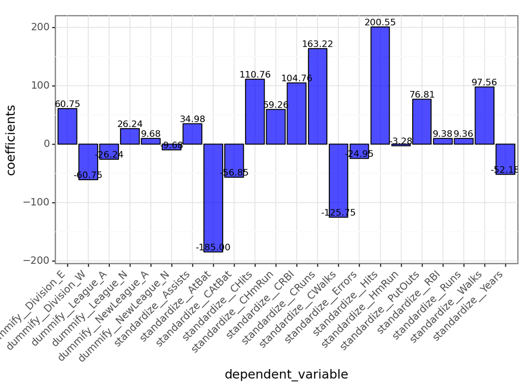

```
<Figure Size: (640 x 480)>
```

```python
# Elastic with all predictors
(ggplot(elastic_coefficients, aes(x='dependent_variable', y='coefficients'))
        + geom_bar(stat='identity', position=position_dodge(width=0.9), fill='blue', color='black', alpha=0.7)
        + geom_text(aes(label='coefficients'), position=position_dodge(width=0.9), size=8, va='bottom', format_string='{:.2f}')
        + theme_bw()
        + theme(axis_text_x=element_text(angle=45, hjust=1))
        )
```

This plot shows the coefficients of the predictor variables within my Elastic model that used all the predictor variables within the dataset. We are able to see the coefficients that would have the largest effect on Salary.